# hw_5

Stephanie Tsai

February 15, 2019

```r
library(tidyverse)
library(skimr)
```

## Mammals Life History

Let’s revisit the mammal life history data to practice our `ggplot` skills. Some of the tidy steps will be a repeat from the homework, but it is good practice. The [data](http://esapubs.org/archive/ecol/E084/093/) are from: *S. K. Morgan Ernest. 2003. Life history characteristics of placental non-volant mammals. Ecology 84:3402.*

1. Load the data.

```r
life_history <- read_csv("C:/Users/Stephanie T/Desktop/FRS_417/class_files-master/mammal_lifehistories_v2.csv")
```

2. Use your preferred function to have a look. Do you notice any problems?

```r
skimr::skim(life_history)
```

```
## Skim summary statistics
##  n obs: 1440
##  n variables: 13
##
## -- Variable type:character -------------------------------------------------------------------------------
##  variable missing complete    n min max empty n_unique
##    family       0     1440 1440   6  15     0       96
##     Genus       0     1440 1440   3  16     0      618
##     order       0     1440 1440   7  14     0       17
##   species       0     1440 1440   3  17     0     1191
##
## -- Variable type:numeric ---------------------------------------------------------------------------------
##      variable missing complete    n      mean         sd   p0  p25     p50
##           AFR       0     1440 1440   -408.12     504.97 -999 -999    2.5
##     gestation       0     1440 1440   -287.25     455.36 -999 -999    1.05
##   litter size       0     1440 1440    -55.63     234.88 -999    1    2.27
##  litters/year       0     1440 1440   -477.14     500.03 -999 -999    0.38
##          mass       0     1440 1440 383576.72 5055162.92 -999   50  403.02
##     max. life       0     1440 1440   -490.26     615.3  -999 -999 -999
##       newborn       0     1440 1440   6703.15   90912.52 -999 -999    2.65
##     wean mass       0     1440 1440  16048.93   5e+05    -999 -999 -999
##       weaning       0     1440 1440   -427.17     496.71 -999 -999    0.73
##      p75          p100     hist
##    15.61     210       ▆▁▁▁▁▁▇▁
##     4.5       21.46    ▃▁▁▁▁▁▁▇
##     3.83      14.18    ▁▁▁▁▁▁▁▇
##     1.15       7.5     ▇▁▁▁▁▁▁▇
##  7009.17       1.5e+08 ▇▁▁▁▁▁▁▁
##   147.25    1368       ▇▁▁▃▂▁▁▁
##    98    2250000       ▇▁▁▁▁▁▁▁
##    10          1.9e+07 ▇▁▁▁▁▁▁▁
##     2         48       ▆▁▁▁▁▁▁▇
```

```r
# There are some NAs in the data because there are -999 values
```

3. There are NA’s. How are you going to deal with them?

```r
life_history_identNA <-
  life_history %>%
  na_if("-999") #replace -999 data with NA

life_history_identNA
```

```
## # A tibble: 1,440 x 13
##    order family Genus species   mass gestation newborn weaning `wean mass`
##    <chr> <chr>  <chr> <chr>    <dbl>     <dbl>   <dbl>   <dbl>       <dbl>
##  1 Arti~ Antil~ Anti~ americ~ 4.54e4      8.13   3246.    3           8900
##  2 Arti~ Bovid~ Addax nasoma~ 1.82e5      9.39   5480     6.5           NA
##  3 Arti~ Bovid~ Aepy~ melamp~ 4.15e4      6.35   5093     5.63       15900
##  4 Arti~ Bovid~ Alce~ busela~ 1.50e5      7.9   10167.    6.5           NA
##  5 Arti~ Bovid~ Ammo~ clarkei 2.85e4      6.8      NA    NA             NA
##  6 Arti~ Bovid~ Ammo~ lervia  5.55e4      5.08   3810     4             NA
##  7 Arti~ Bovid~ Anti~ marsup~ 3.00e4      5.72   3910     4.04          NA
##  8 Arti~ Bovid~ Anti~ cervic~ 3.75e4      5.5    3846     2.13          NA
##  9 Arti~ Bovid~ Bison bison   4.98e5      8.93  20000    10.7       157500
## 10 Arti~ Bovid~ Bison bonasus 5.00e5      9.14  23000.    6.6           NA
## # ... with 1,430 more rows, and 4 more variables: AFR <dbl>, `max.
## #   life` <dbl>, `litter size` <dbl>, `litters/year` <dbl>
```

```r
skim(life_history_identNA)
```

```
## Skim summary statistics
##  n obs: 1440
##  n variables: 13
##
## -- Variable type:character -------------------------------------------------------------------------------
##  variable missing complete    n min max empty n_unique
##    family       0     1440 1440   6  15     0       96
##     Genus       0     1440 1440   3  16     0      618
##     order       0     1440 1440   7  14     0       17
##   species       0     1440 1440   3  17     0     1191
##
## -- Variable type:numeric ---------------------------------------------------------------------------------
##      variable missing complete    n      mean         sd    p0   p25
##           AFR     607      833 1440     22.44      26.45  0.7   4.5
##     gestation     418     1022 1440      3.86       3.62  0.49  0.99
##   litter size      84     1356 1440      2.8        1.77  1     1.02
##  litters/year     689      751 1440      1.64       1.17  0.14  1
##          mass      85     1355 1440 407701.39 5210474.99  2.1  61.15
##     max. life     841      599 1440    224.03     189.74 12    84
##       newborn     595      845 1440  12126.55  118408.21  0.21  4.4
##     wean mass    1039      401 1440  60220.5   953857.17  2.09 20.15
##       weaning     619      821 1440      3.97       5.38  0.3   0.92
##     p50     p75          p100     hist
##   12      28.24     210       ▇▂▁▁▁▁▁▁
##    2.11    6         21.46    ▇▂▂▁▁▁▁▁
##    2.5     4         14.18    ▇▃▂▁▁▁▁▁
##    1       2          7.5     ▇▂▃▁▁▁▁▁
##  606    8554          1.5e+08 ▇▁▁▁▁▁▁▁
##  192     288       1368       ▇▆▂▁▁▁▁▁
##   43.7   542.5  2250000       ▇▁▁▁▁▁▁▁
##  102.6  2000          1.9e+07 ▇▁▁▁▁▁▁▁
##    1.69    4.84      48       ▇▁▁▁▁▁▁▁
```

4. Where are the NA’s? This is important to keep in mind as you build plots.

```r
# The NAs are all in the numeric data. It is not in the order, family, genus, and species.
```

5. Some of the variable names will be problematic. Let’s rename them here as a final tidy step.

```r
tidy_lifeHistory <- life_history_identNA %>%
rename(genus = 'Genus',
          wean_mass = 'wean mass',
          max_life = 'max. life',
          litter_size = 'litter size',
          litters_yr = 'litters/year')

names(tidy_lifeHistory)
```

```
##  [1] "order"       "family"      "genus"       "species"     "mass"
##  [6] "gestation"   "newborn"     "weaning"     "wean_mass"   "AFR"
## [11] "max_life"    "litter_size" "litters_yr"
```

## `ggplot()`

For the questions below, try to use the aesthetics you have learned to make visually appealing and informative plots. Make sure to include labels for the axes and titles.

options(scipen=999) #cancels the use of scientific notation for the session

6. What is the relationship between newborn body mass and gestation? Make a scatterplot that shows this relationship.

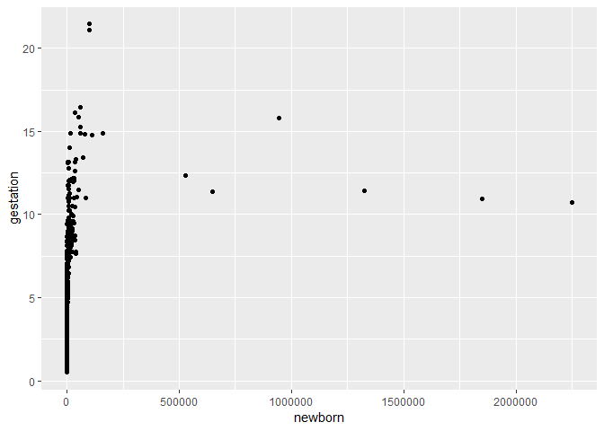

```r
options(scipen=999)

tidy_lifeHistory %>%
  ggplot(aes(x = newborn, y = gestation)) +
  geom_point()
```

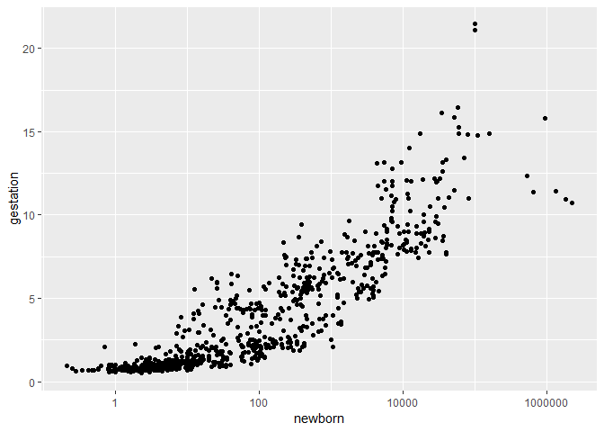

```r
tidy_lifeHistory %>%
  ggplot(aes(x = newborn, y = gestation)) +
  scale_x_log10() +
  geom_point()
```